# TP3 - Eloisa Ostrogovich Escher

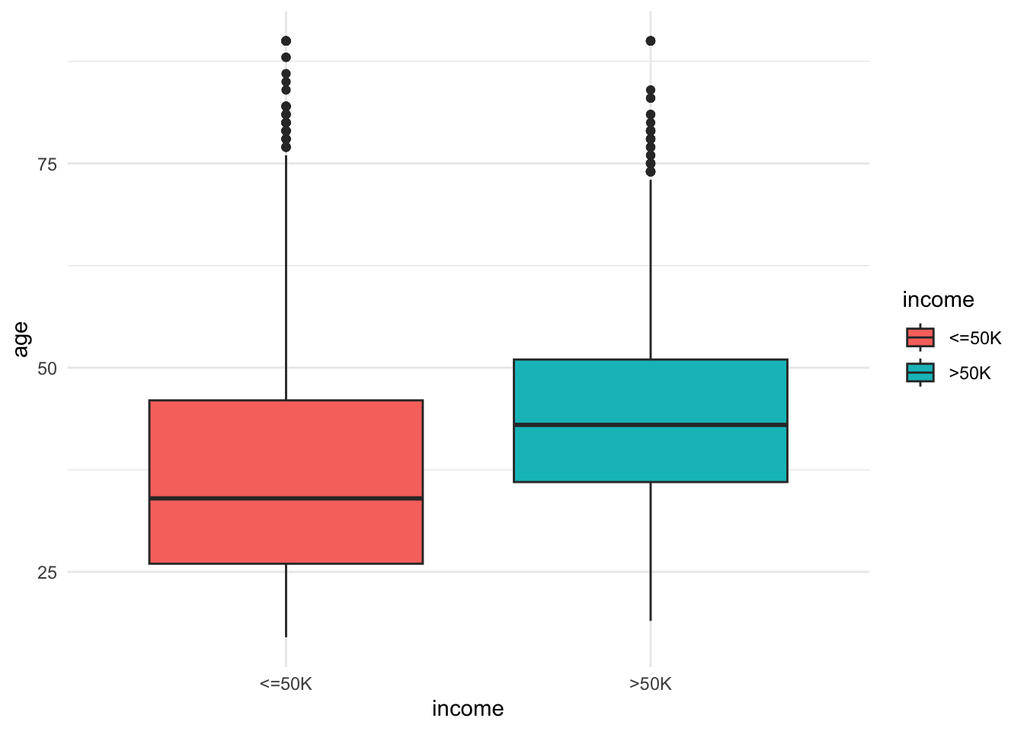

```r
grafico4 <- ggplot(censo, aes(x = income, y = age, fill = income)) +
  geom_boxplot() +
  theme_minimal()

print(grafico4)
```

El gráfico hace una comparación entre la edad y el ingreso, mostrando que las personas con ingresos superiores a 50K presentan una edad media mayor. Esto muestra una asociación positiva entre los años e trabajo y el nivel de ingresos.

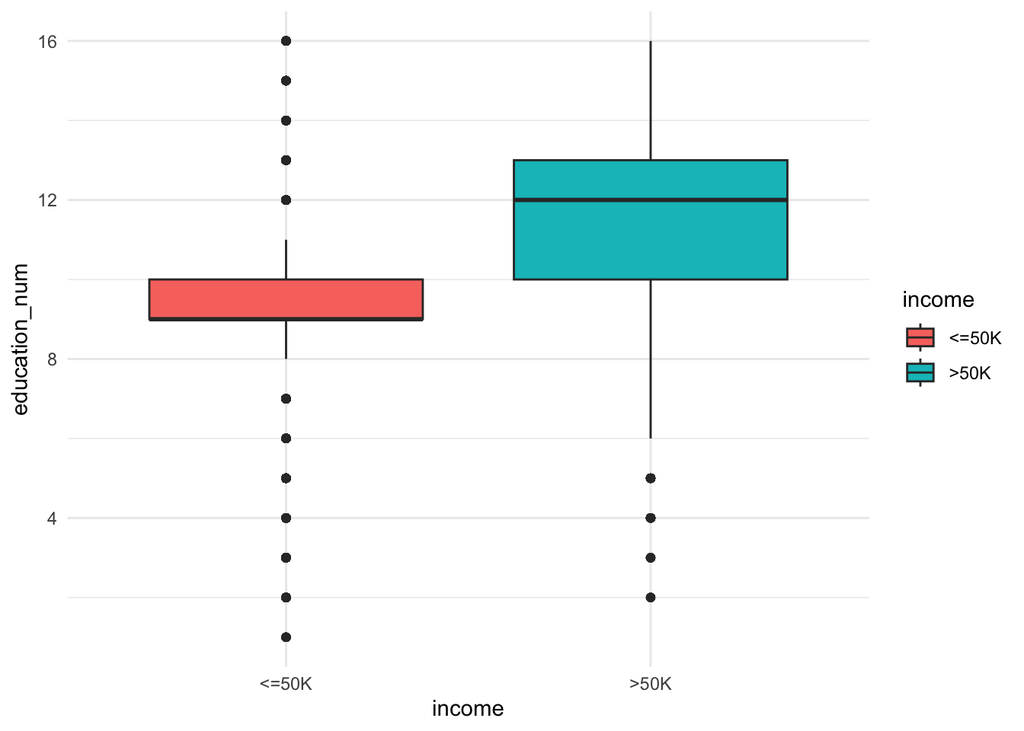

```r
grafico5 <- ggplot(censo, aes(x = income, y = education_num, fill = income)) +
  geom_boxplot() +
  theme_minimal()

print(grafico5)
```

Este gráfico compara el nivel educativo con el grupo de ingresos, indicando que las personas con ingresos mayores a 50K tienen mas años de educación.

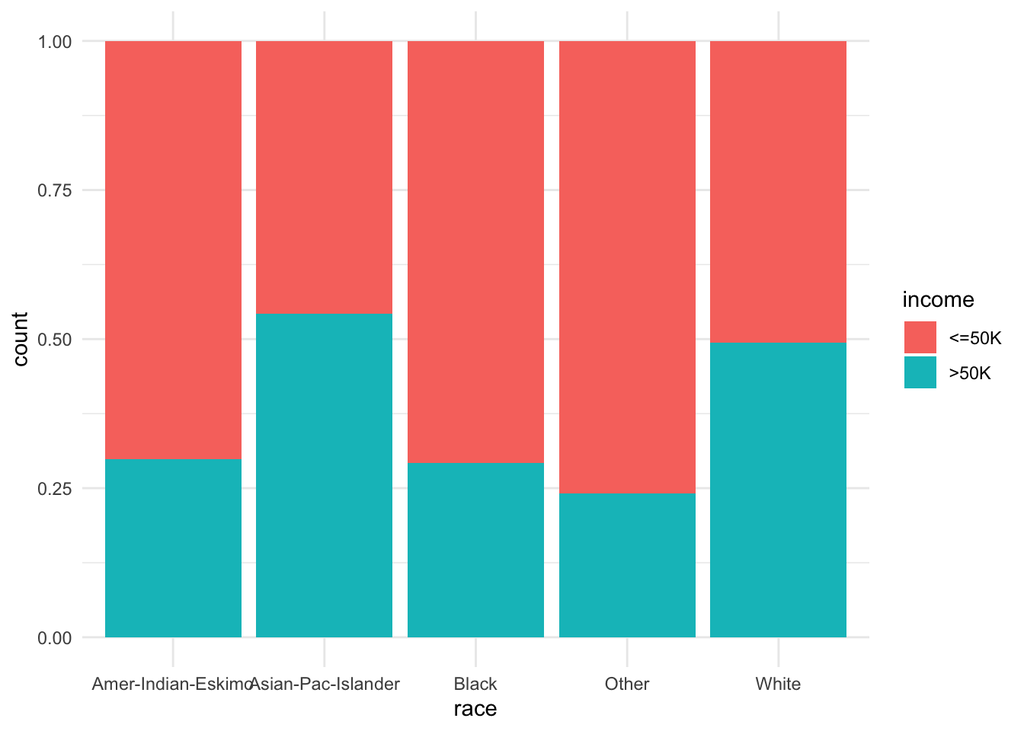

```r
grafico6 <- ggplot(censo, aes(x = race, fill = income)) +
  geom_bar(position = "fill") +
  theme_minimal()

print(grafico6)
```

## Distribución de ingreso y marital status

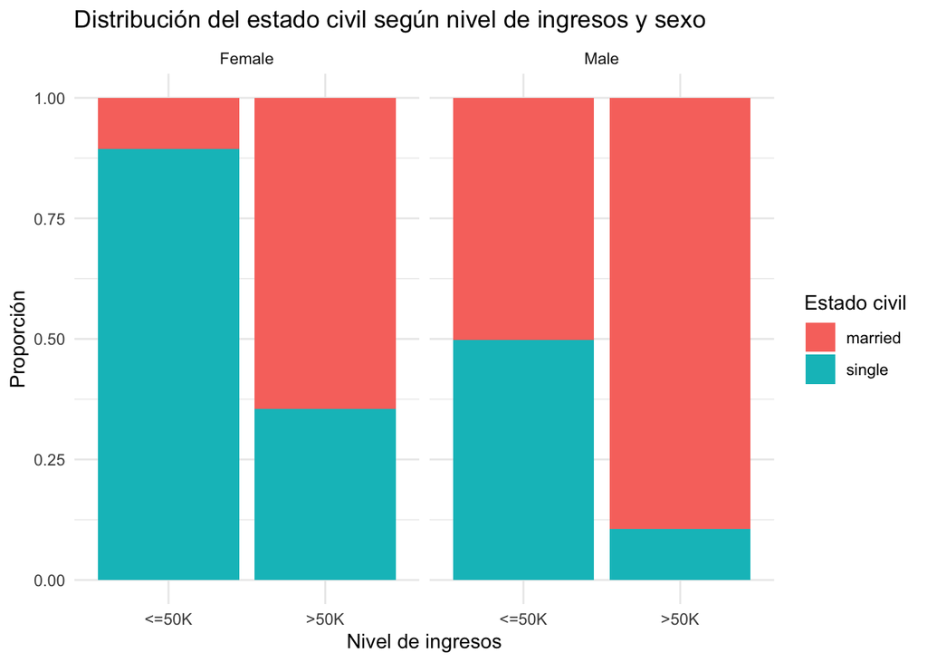

```r
ingreso_marital <- ggplot(censo, aes(x = income, fill = marital_status)) +
  geom_bar(position = "fill") +
  facet_wrap(~ sex) +
  labs(
    title = "Distribución del estado civil según nivel de ingresos y sexo",
    x = "Nivel de ingresos",
    y = "Proporción",
    fill = "Estado civil"
  ) +
  theme_minimal()

print(ingreso_marital)
```

El gráfico muestra la composición del estado civil para ambos niveles de ingresos no es el mismo para hombres que para mujeres. La mayoría de las mujeres con ingresos menores a 50K se encuentran solteras, mientras que para las mujeres casadas aumenta la proporción de ingresos mayores a 50K. Esto demuestra que estar casada se asocia con un aumento de ingresos entre las mujeres. Del lado de los hombres, se observa una situación similar al de las mujeres, pero en menor medida. El grupo de ingresos menores a 50K muestra una distribución pareja entre ambos estados civiles, mientras que para el grupo de ingresos mayores a 50K la proporcion de hombres solteras es significativamente pequeña. En ambos géneros podemos observar que estar casado aumenta la proporción de ingresos de las personas.

## Regresión logística

### Modelo 1

```r
modelo_base <- glm(income ~ age + education_num + marital_status + race + sex + hours_per_week,
                   data = censo, family = binomial)

stargazer::stargazer(modelo_base, type = "text", star.cutoffs = c(0.05, 0.01, 0.001),
                     report = "vc*sp", no.space = T)
```

```
====================================================
                            Dependent variable:
                       -----------------------------
                                  income
----------------------------------------------------
age                              0.038***
                                  (0.002)
                                 p = 0.000
education_num                    0.390***
                                  (0.010)
                                 p = 0.000
marital_statussingle             -2.294***
                                  (0.050)
                                 p = 0.000
raceAsian-Pac-Islander             0.327
                                  (0.287)
                                 p = 0.255
raceBlack                          0.187
                                  (0.269)
                                 p = 0.489
raceOther                         -0.378
                                  (0.408)
                                 p = 0.355
raceWhite                          0.399
                                  (0.259)
                                 p = 0.123
sexMale                          0.226***
                                  (0.054)
                                p = 0.00004
hours_per_week                   0.035***
                                  (0.002)
                                 p = 0.000
Constant                         -6.988***
                                  (0.303)
                                 p = 0.000
----------------------------------------------------
Observations                      15,766
Log Likelihood                  -7,085.178
Akaike Inf. Crit.               14,190.350
====================================================
Note:                  *p<0.05; **p<0.01; ***p<0.001
```

Los coeficientes para age, education_num, sexMale y hours_per_week son positivos y altamente significativos. Esto indica que a mayor edad, más años de educación formal y más horas dedicadas al trabajo a la semana, se incrementan las log-odds y la probabilidad de pertenecer al grupo de ingresos altos. El coeficiente de marital_statussingle es negativo y muy significativo, confirmando la disminución de ingresos asociada a la soltería bajo este modelo.